# 2575976_Day-10_Excercise-2

```python
import numpy as np
import pandas as pd
import matplotlib.pyplot as plt
```

```python
d=pd.read_csv("titles.csv")
titles_df=pd.DataFrame(d)
```

```python
titles_df
```

|  | title | year |
| --- | --- | --- |
| 0 | Tasveer Mere Sanam | 1996 |
| 1 | Only You | 1994 |
| 2 | El pueblo del terror | 1970 |
| 3 | Machine | 2007 |
| 4 | MARy | 2008 |
| ... | ... | ... |
| 244909 | Black Butterfly in a Colorful World | 2018 |
| 244910 | Hua fei hua wu chun man cheng | 1980 |
| 244911 | Nippon dabi katsukyu | 1970 |
| 244912 | Under Siege 2: Dark Territory | 1995 |
| 244913 | She Must Be Seeing Things | 1987 |

244914 rows × 2 columns

```python
d=pd.read_csv("cast.csv")
cast_df=pd.DataFrame(d)
```

```python
cast_df
```

|  | title | year | name | type | character | n |
| --- | --- | --- | --- | --- | --- | --- |
| 0 | Closet Monster | 2015 | Buffy #1 | actor | Buffy 4 | 31.0 |
| 1 | Suuri illusioni | 1985 | Homo $ | actor | Guests | 22.0 |
| 2 | Battle of the Sexes | 2017 | $hutter | actor | Bobby Riggs Fan | 10.0 |
| 3 | Secret in Their Eyes | 2015 | $hutter | actor | 2002 Dodger Fan | NaN |
| 4 | Steve Jobs | 2015 | $hutter | actor | 1988 Opera House Patron | NaN |
| ... | ... | ... | ... | ... | ... | ... |
| 3786171 | Foxtrot | 1988 | Lilja ??risd?ttir | actress | D?ra | 24.0 |
| 3786172 | Niceland (Population. 1.000.002) | 2004 | Sigr??ur J?na ??risd?ttir | actress | Woman in Bus | 26.0 |
| 3786173 | Skammdegi | 1985 | Dalla ??r?ard?ttir | actress | Hj?krunarkona | 9.0 |
| 3786174 | U.S.S.S.S... | 2003 | Krist?n Andrea ??r?ard?ttir | actress | Afgr.dama ? bens?nst?? | 17.0 |
| 3786175 | Bye Bye Blue Bird | 1999 | Rosa ? R?gvu | actress | Pensionatv?rtinde | NaN |

3786176 rows × 6 columns

# 1.what are the ten most common movie names of all time?

```python
title_counts = titles_df['title'].value_counts()

top_ten_titles = title_counts.head(10)

print("Top Ten Most Common Movie Names of All Time:")
print(top_ten_titles)
```

```
Top Ten Most Common Movie Names of All Time:
Hamlet                  20
Carmen                  17
Macbeth                 16
The Outsider            12
Maya                    12
Temptation              12
Freedom                 11
Honeymoon               11
Othello                 11
The Three Musketeers    11
Name: title, dtype: int64
```

# 2.which three years of the 1930s saw the most films released?

```python
movies_1930s = titles_df[(titles_df['year'] >= 1930) & (titles_df['year'] <= 1939)]

movie_counts_by_year = movies_1930s['year'].value_counts()

top_three_years = movie_counts_by_year.head(3)

print("Top Three Years in the 1930s with the Most Films Released:")
print(top_three_years)
```

```
Top Three Years in the 1930s with the Most Films Released:
1937    1224
1936    1169
1938    1163
Name: year, dtype: int64
```

# 3.Plot the number of films that have been released each decade over the history of cinema.

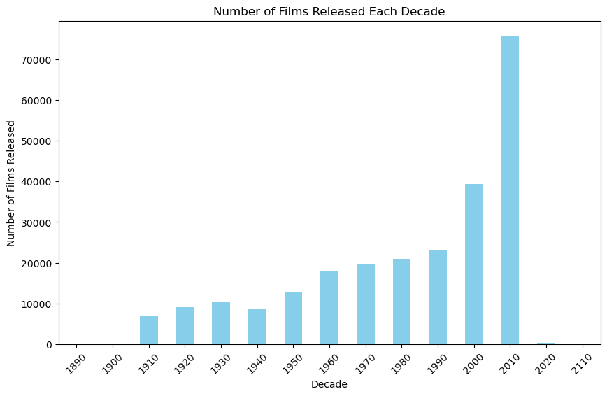

```python
titles_df['decade'] = (titles_df['year'] // 10) * 10

films_per_decade = titles_df['decade'].value_counts().sort_index()

plt.figure(figsize=(10, 6))
films_per_decade.plot(kind='bar', color='skyblue')
plt.title('Number of Films Released Each Decade')
plt.xlabel('Decade')
plt.ylabel('Number of Films Released')
plt.xticks(rotation=45)
plt.show()
```

# 4.Plot the number of "Hamlet" films made each decade.

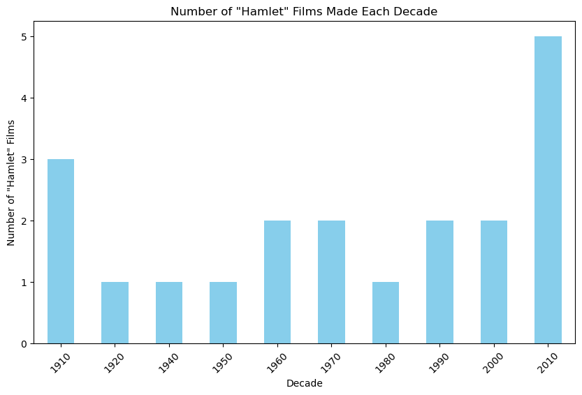

```python
hamlet_films = titles_df[titles_df['title'] == "Hamlet"]

hamlet_films['decade'] = (hamlet_films['year'] // 10) * 10

hamlet_films_per_decade = hamlet_films['decade'].value_counts().sort_index()

plt.figure(figsize=(10, 6))
hamlet_films_per_decade.plot(kind='bar', color='skyblue')
plt.title('Number of "Hamlet" Films Made Each Decade')
plt.xlabel('Decade')
plt.ylabel('Number of "Hamlet" Films')
plt.xticks(rotation=45)
plt.show()
```

# 5.Plot the number of "Rustler" characters in each decade of the history of film.

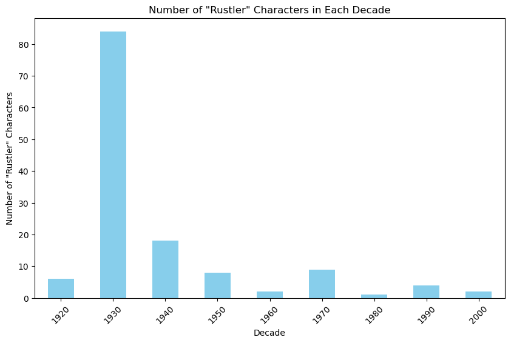

```python
rustler_characters = cast_df[cast_df['character'] == "Rustler"]

rustler_characters['decade'] = (rustler_characters['year'] // 10) * 10

rustler_characters_per_decade = rustler_characters['decade'].value_counts().sort_index()

plt.figure(figsize=(10, 6))
rustler_characters_per_decade.plot(kind='bar', color='skyblue')
plt.title('Number of "Rustler" Characters in Each Decade')
plt.xlabel('Decade')
plt.ylabel('Number of "Rustler" Characters')
plt.xticks(rotation=45)
plt.show()
```

# 6.Plot the number of "Hamlet" characters each decade.

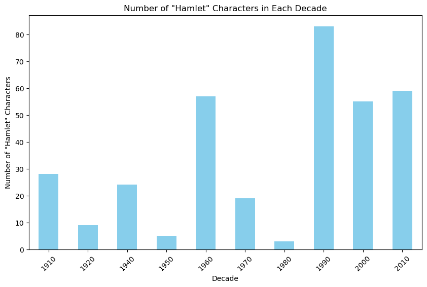

```python
hamlet_cast = cast_df[cast_df['title'] == "Hamlet"]

hamlet_cast['decade'] = (hamlet_cast['year'] // 10) * 10

hamlet_characters_per_decade = hamlet_cast['decade'].value_counts().sort_index()

plt.figure(figsize=(10, 6))
hamlet_characters_per_decade.plot(kind='bar', color='skyblue')
plt.title('Number of "Hamlet" Characters in Each Decade')
plt.xlabel('Decade')
plt.ylabel('Number of "Hamlet" Characters')
plt.xticks(rotation=45)
plt.show()
```

# 7.What are the 11 most common character names in movie history?

```python
top_11_characters = character_counts.head(11)

print("Top 11 Most Common Character Names in Movie History:")
print(top_11_characters)
```

```
Top 11 Most Common Character Names in Movie History:
Himself        20746
Dancer         12477
Extra          11948
Reporter        8434
Student         7773
Doctor          7669
Party Guest     7245
Policeman       7029
Nurse           6999
Bartender       6802
Herself         6705
Name: character, dtype: int64
```

# 9.Who are the 10 people most often credited as "Herself" in film history?

```python
herself_credits = cast_df[cast_df['character'] == "Herself"]

herself_counts = herself_credits['name'].value_counts()

top_10_herself_credits = herself_counts.head(10)

print("Top 10 People Most Often Credited as 'Herself' in Film History:")
print(top_10_herself_credits)
```

```
Top 10 People Most Often Credited as 'Herself' in Film History:
Queen Elizabeth II           12
Joyce Brothers                9
Luisa Horga                   9
Mar?a Luisa (V) Mart?n        9
Margaret Thatcher             8
Hillary Clinton               8
In?s J. Southern              6
Mar?a Isabel (III) Mart?n     6
Marta Berrocal                6
Sumie Sakai                   6
Name: name, dtype: int64
```

# 10.Who are the 10 people most often credited as "Himself" in film history?

```python
himself_credits = cast_df[cast_df['character'] == "Himself"]

himself_counts = himself_credits['name'].value_counts()

top_10_himself_credits = himself_counts.head(10)

print("Top 10 People Most Often Credited as 'Himself' in Film History:")
print(top_10_himself_credits)
```

```
Top 10 People Most Often Credited as 'Himself' in Film History:
Adolf Hitler             99
Richard Nixon            44
Ronald Reagan            41
John F. Kennedy          37
George W. Bush           25
Winston Churchill        24
Martin Luther King       23
Ron Jeremy               22
Bill Clinton             22
Franklin D. Roosevelt    21
Name: name, dtype: int64
```

# 11.Which actors or actresses appeared in the most movies in the year 1945?

```python
movies_1945 = cast_df[cast_df['year'] == 1945]

top_actors_1945 = movies_1945['name'].value_counts()

most_appearances_1945 = top_actors_1945.idxmax()

most_appearances_count_1945 = top_actors_1945.max()

print(f"The actor/actress who appeared in the most movies in 1945 is {most_appearances_1945} with {most_appearances_count_1945} appearances.")
```

```
The actor/actress who appeared in the most movies in 1945 is Emmett Vogan with 39 appearances.
```

# 12.Which actors or actresses appeared in the most movies in the year 1985?

```python
movies_1985 = cast_df[cast_df['year'] == 1985]

top_actors_1985 = movies_1985['name'].value_counts()

most_appearances_1985 = top_actors_1985.idxmax()

most_appearances_count_1985 = top_actors_1985.max()

print(f"The actor/actress who appeared in the most movies in 1985 is {most_appearances_1985} with {most_appearances_count_1985} appearances.")
```

```
The actor/actress who appeared in the most movies in 1985 is Mammootty with 22 appearances.
```